# Langt verkefni 3

Adalheidur Magnusdottir og Sigrún Erna Kristinsdóttir

2023-03-02

# Aðferð

Gögnin eru tilbúin gögn sem fengin voru frá James o.fl. (2013). Upprunlegu gögnin innihalda 12 breytur en hér er unnið með 7 breytur og 400 svör. Breyturnar eru innkoma í 1.000 dollurum, hámarks innistæða á kredikoti, lánshæfimat, fjöldi kreditkorta, aldur sem mældur var í árum, menntun sem var fjöldi ára í skóla og meðalinnistæða á kredikorti.  
Markmið greiningarinnar er að athuga tengsli á milli breytanna, framkvæma marghliða aðfallsgreiningu, leggja mat á forsendur líkana og umbreyta gögnunum. Tengsl breytanna var kannað með fylgnifylki og unnið var með þær breytur sem höfðu hæstu fylgni við hvor aðra. Marghliða aðfallsgreining var framkvæmd en hún gerir kleift að spá fyrir um gildi fylgibreytu út frá fleiri en einni frumbreytu. Hallastuðullinn lýsir þá breytingu á gildi fylgibreytu þegar frumbreyta hækkar eða lækkar um eina einingu, þegar leiðrétt er fyrir áhrifum annarra frumbreyta. Forsendur voru kannaðar fyrir líkanið með út frá línulegum tengslum, normaldreifingu og einsleitni villu. Það var skoðað með leifarriti, normalriti, breiddar- og staðsetningariti og áhrifariti. Að því loknu var kannað hvort bæta mætti líkanið og forsendur þess með umbreytingum. Umbreytingar leiðrétta fyrir vandamálum ef þau eru til staðar, þær draga úr skekkju af völdum frávillinga en viðhalda sömu eiginleikum og upprunalegu gögnin. Markmiðið var að enda með lokalíkan sem veitir bestu forspá og hefur ásættanlegar forsendur.

# Niðurstöður

Við forathugun gagna er byrjað á að athuga lýsandi tölfræði breyta, sjá töflu 1. Á mynd 1 má svo sjá fylgnifylki sem sýnir fylgni milli breytanna. Jákvæð fylgni er á milli innkomu, lánshæfnimats og meðalinnistæðu og líklegt að þessar breytur henti við úrvinnslu.

Tafla 1. Lýsandi tölfræði breytanna

|  | Meðaltal | Staðalfrávik |
| --- | --- | --- |
| Innkoma (í 1000$) | 45.22 | 35.24 |
| Hámarks innistæða á kreditkorti | 4735.60 | 2308.20 |
| Lánshæfimat | 354.94 | 154.72 |
| Fjöldi korta | 2.96 | 1.37 |
| Aldur | 55.67 | 17.25 |
| Menntun | 13.45 | 3.13 |
| Meðalinnistæða á kredikorti | 520.02 | 459.76 |

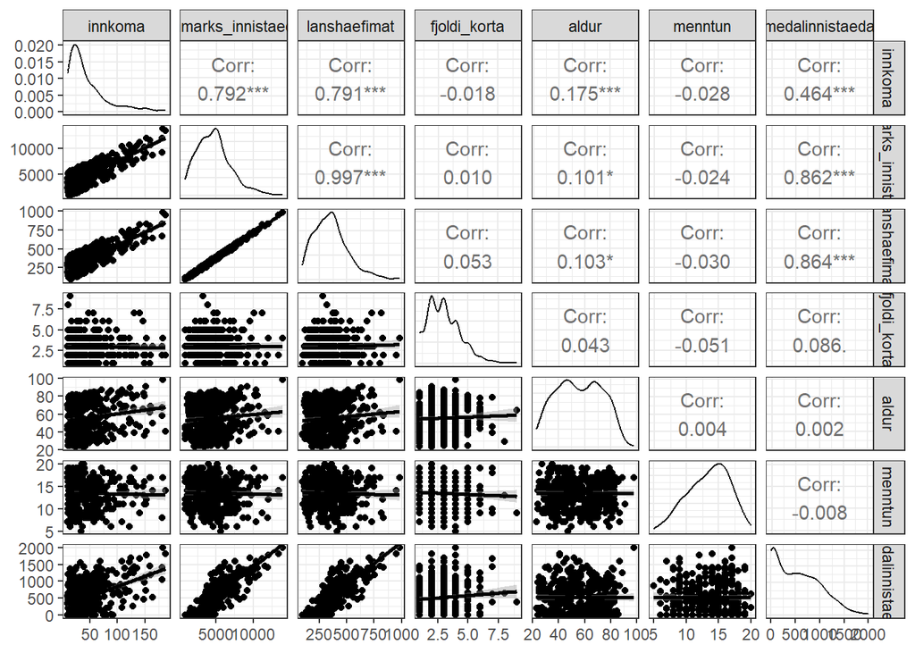

### Marghliða aðfallsgreining

Líkan 1 er spálíkan þar sem spáð var fyrir um lánshæfnimat út frá innkomu og meðalinnistæðu kreditkorta einstaklings. Á töflu 2 má sjá niðurstöður líkans 1.

| Observations | 400 |
| --- | --- |
| Dependent variable | lanshaefimat |
| Type | OLS linear regression |

| F(2,397) | 3140.33 |
| --- | --- |
| R² | 0.94 |
| Adj. R² | 0.94 |

|  | Est. | S.E. | t val. | p |
| --- | --- | --- | --- | --- |
| (Intercept) | 145.35 | 3.28 | 44.25 | 0.00 |
| innkoma | 2.19 | 0.06 | 36.06 | 0.00 |
| medalinnistaeda | 0.21 | 0.00 | 45.81 | 0.00 |

Standard errors: OLS

### Forsendur líkansins

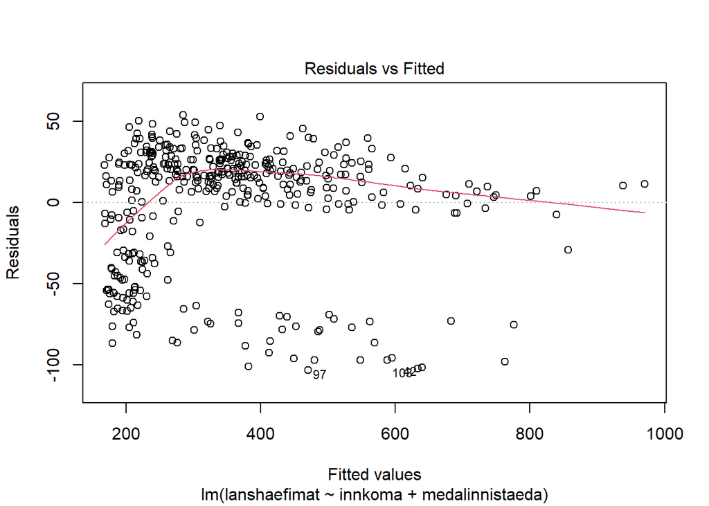

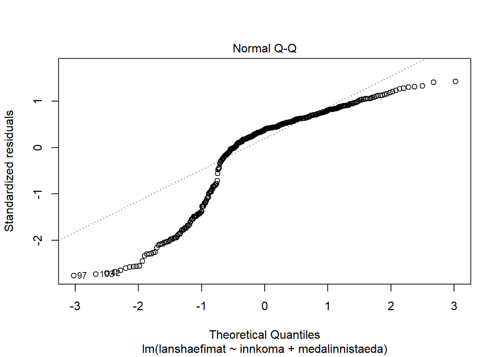

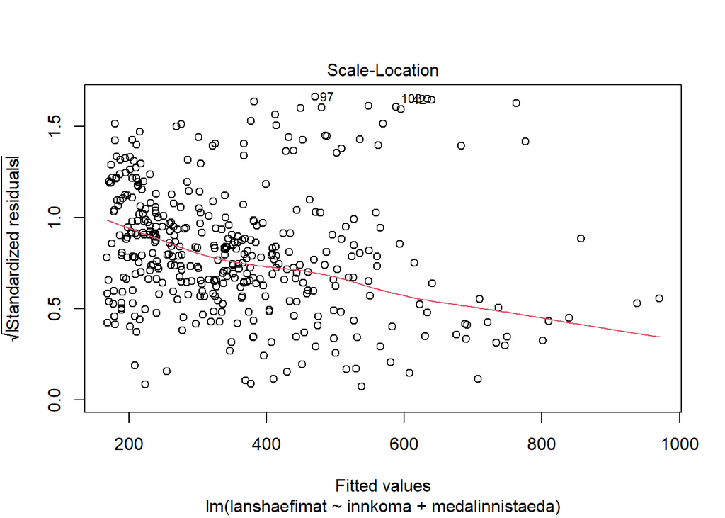

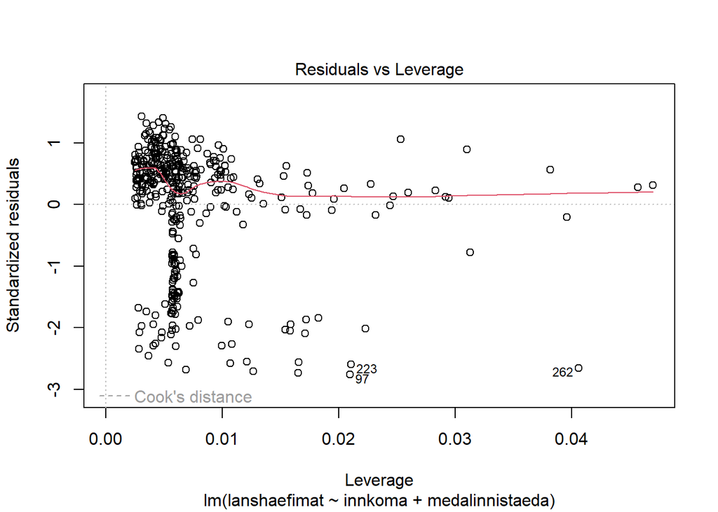

### Umbreytingar

Umbreytingum var beitt á breyturnar innkoma, meðalinnistæða og lánshæfimat. Notaður var lógariþmi þar sem jákvæð skekkja var til staðar í dreifingum allra breytanna. Lógariþmi þjappar hægri hala dreifingar saman og getur því hjálpað þegar jákvæð skekkja er vandamál. Þar sem breytan meðal innistæða inniheldur núll gildi var ákveðið að bæta 1 við öll gildi þegar umbreyting var framkvæmd. Kostur slíkrar meðhöndlunar gilda er að log(1)=0, og núll-gildi munu því haldast eftir umbreytingu. Lógariþmísk umbreyting er helst notuð þegar leysa þarf vanda vegna jákvæðrar skekkju og ójafnrar dreifingar og hentar því vel í þessu tilviki. Hér að neðan má sjá dreifingu breytanna fyrir og eftir umbreytingar. Eftir umbreytingar er dreifing ekki lengur jafn áberandi mikið jákvætt skekkt.

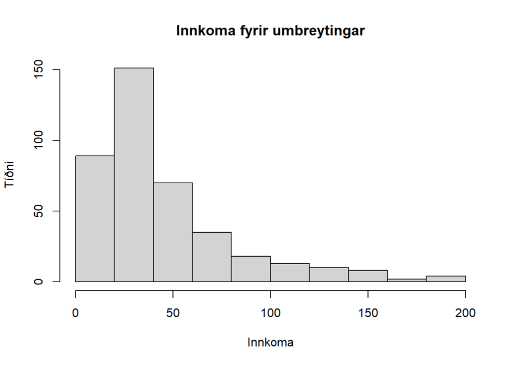

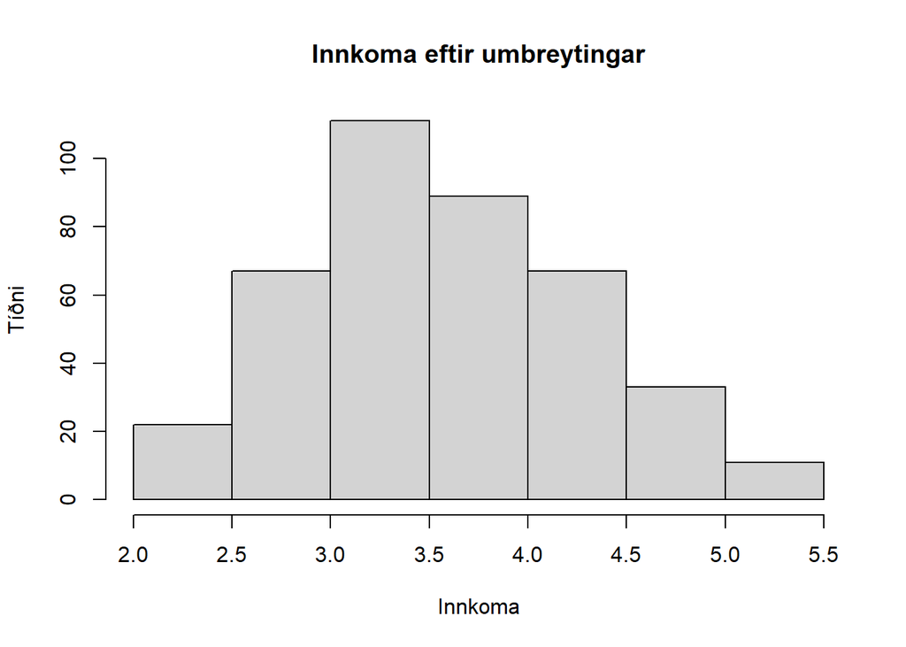

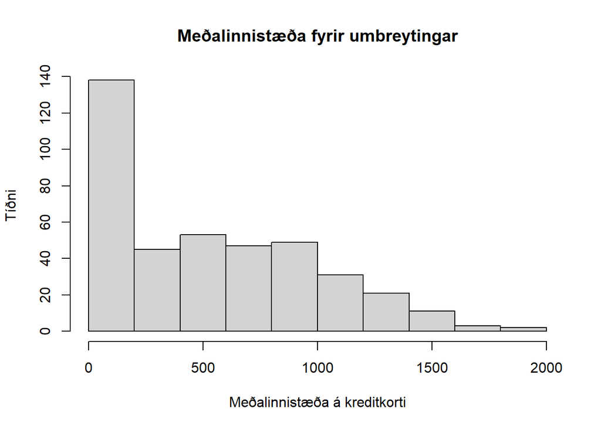

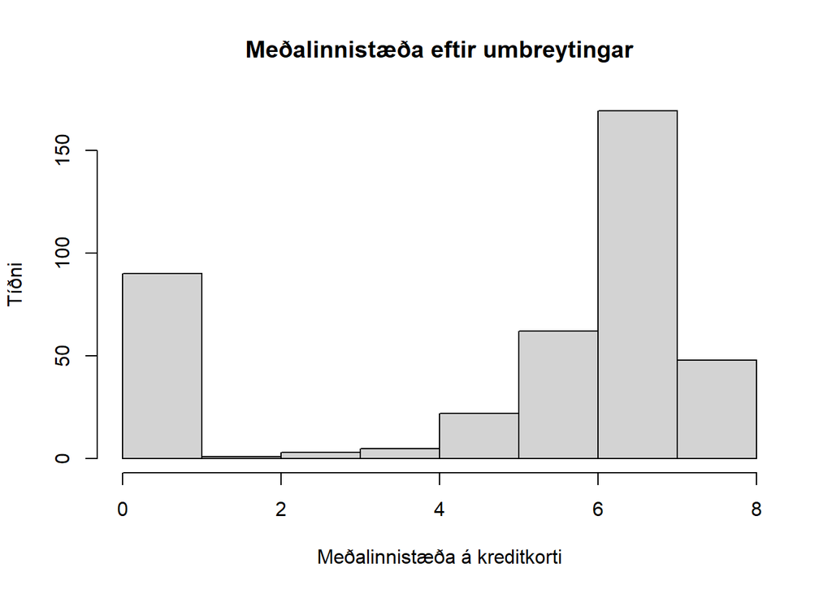

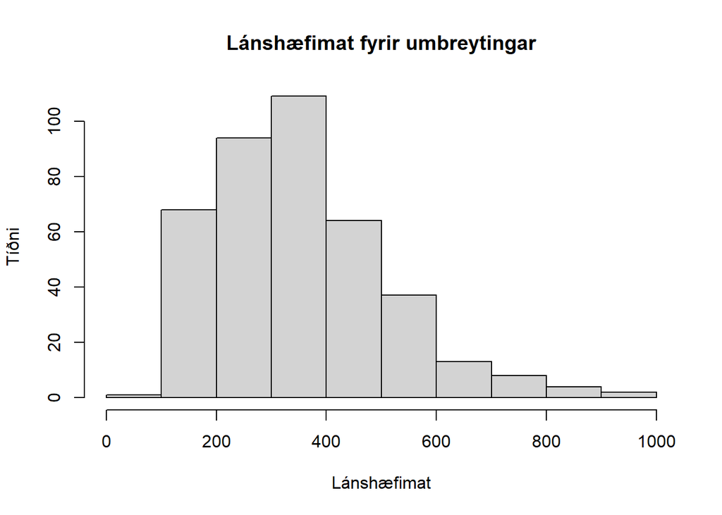

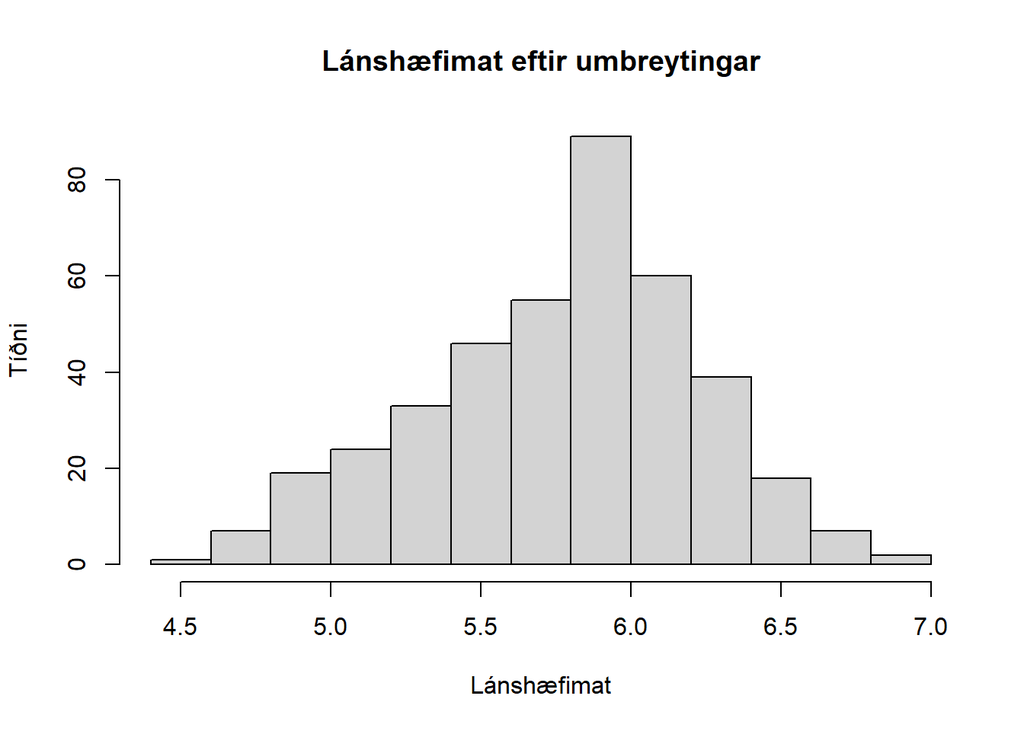

### Forsendur líkansins eftir umbreytingar

Því næst er athugað hvort forsendur haldi betur eftir umbreytingu, en aðfallsgreining er talin nokkuð traust gagnvart frávikum frá normaldreifingu.

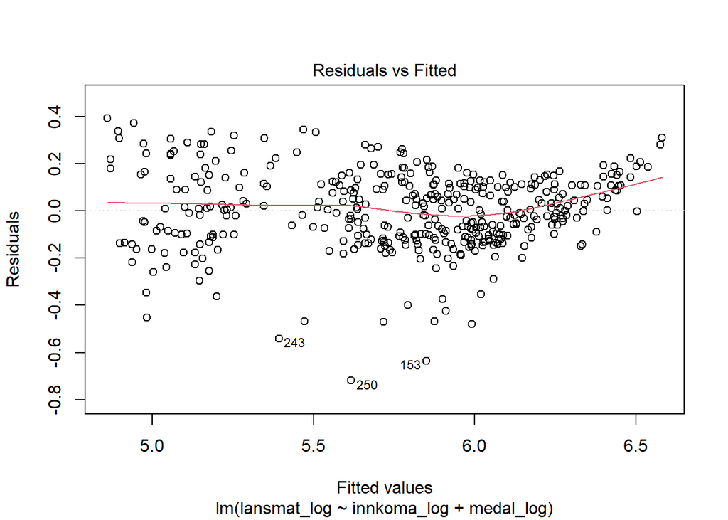

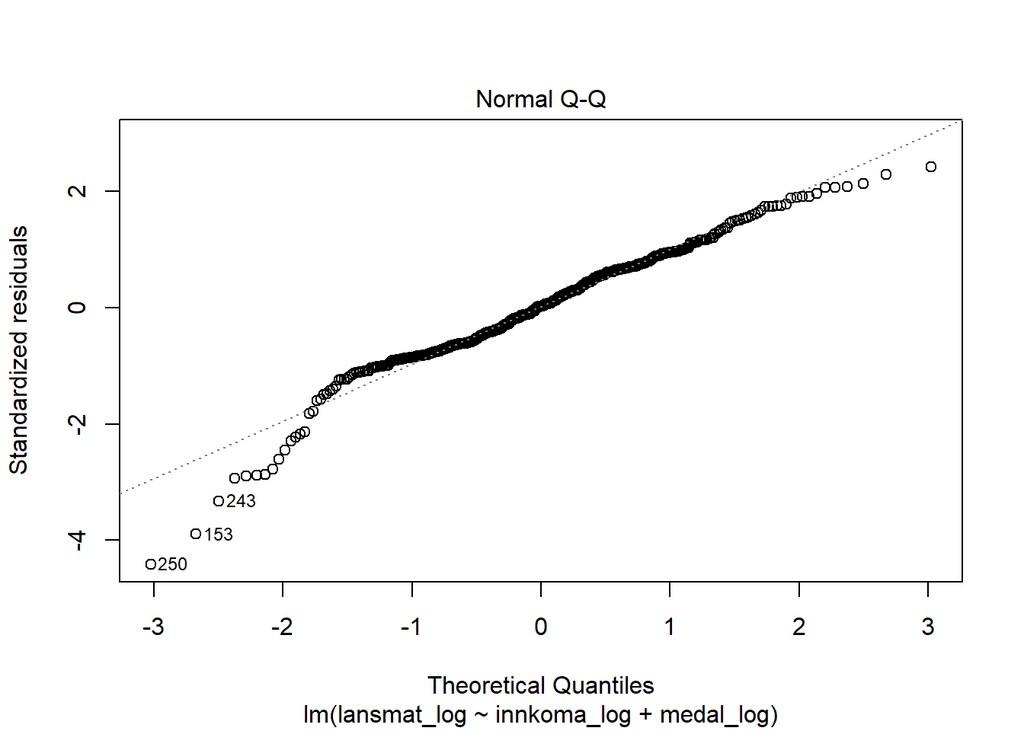

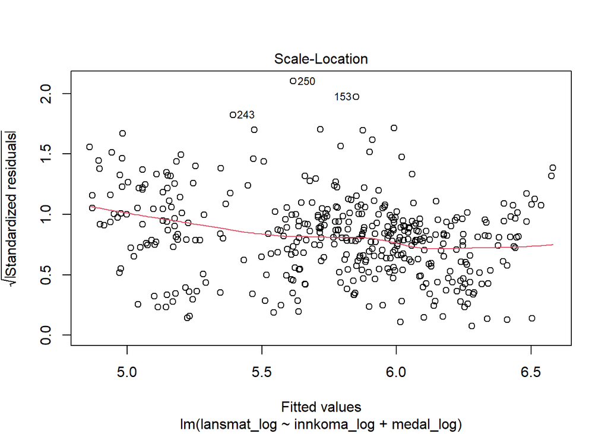

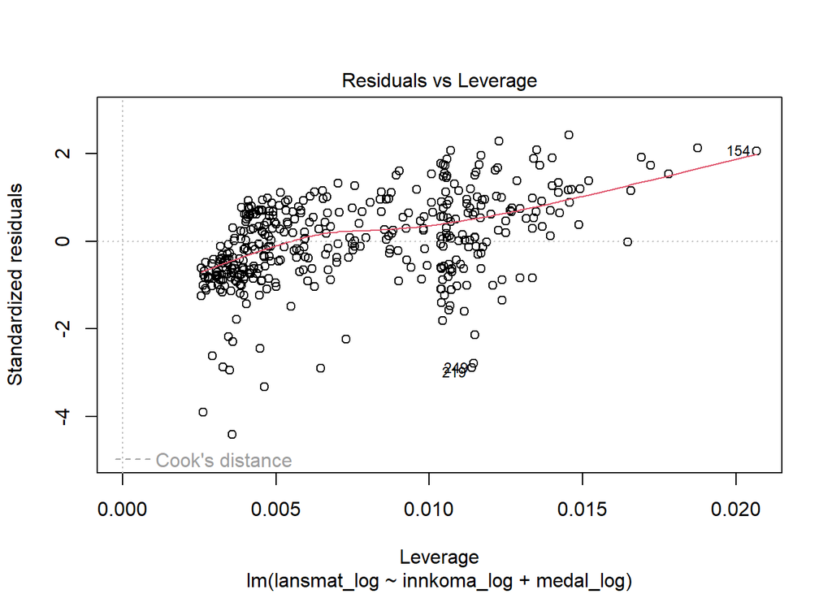

Myndirnar hér fyrir ofan sýna forsendur líkansins eftir umbreytingar. Eins og sjá má á leifariti er dreifing nokkuð jöfn og ekki áberandi mynstur, og því hægt að álykta sem svo að forsendur gagnvart línulegum tengslum og einsleitni haldist. Einsleitni verður athuguð nánar í breiddar- og staðsetningarriti.  
Þegar litið er til normalritsins (*Normal Q-Q plot*) má sjá hvernig leif dreifist í samanburði við fullkomna normaldreifingu, og nokkuð ljóst að dreifing leifar eftir umbreytingu nálgast normaldreifingu.  
Til að meta einsleitni villu er horft til breiddar- og staðsetningarrits (*Scale-Location*) sem gefur dreifingu leifar þar sem spágildi eru á x-ás og stöðluð leif á y-ás. Ritið gefur til kynna að dreifing leifar nokkuð jöfn.  
Áhrifaritið gefur leif miðað við Cook’s distance, og er notað til að finna áhrifamestu gildin. Eftir umbreytingu gefur áhrifaritið þó enn til kynna að áhrifamestu gildin séu enn öfgagildi.

Tafla 3: Niðurstöður marghliða aðfallsgreiningar, fyrir og eftir umbreytingu

|  | Líkan 1 | Líkan eftir umbreytingu |
| --- | --- | --- |
| (Intercept) | 145.351*** | 4.167*** |
|  | (3.285) | (0.043) |
| innkoma | 2.186*** |  |
|  | (0.061) |  |
| medalinnistaeda | 0.213*** |  |
|  | (0.005) |  |
| innkoma_log |  | 0.296*** |
|  |  | (0.012) |
| medal_log |  | 0.114*** |
|  |  | (0.003) |
| R<sup>2</sup> | 0.941 | 0.871 |
| Adj. R<sup>2</sup> | 0.940 | 0.870 |
| Num. obs. | 400 | 400 |

***p < 0.001; **p < 0.01; *p < 0.05

# Heimildir

James, G., Witten, D., Hastie, T., and Tibshirani, R. (2013) An Introduction to Statistical Learning with applications in R, https://www.statlearning.com, Springer-Verlag, New York